# Resampling Methods

Bhanu_Prakash

7/25/2021

# Resampling Methods

A machine learning professor and his long-term girlfriend are planning to tie the knot. He had never been diamond shopping before. He was surrounded by a bewildering array of diamond features, arrangements, and pricing in the mall.he discovered that diamonds are essentially defined by polish, symmetry, and certification, other factors to consider are colour, cut, carat weight, and clarity.

Linear Regression Model is already built to predict the price. we will cross validate and Bootstrap the regression

```r
library(openxlsx)
library(dplyr)
library(tidyverse)
library(caret)
library(boot)
```

## summary statistics

The minimum, first quartile, median, mean, third quartile, and maximum values are included in the metric data summary. The summary of non-metric data, on the other hand, includes a summary of length, class, and mode.

```r
df1 <- read.xlsx(xlsxFile = "MBA6636_SM21_Professor_Proposes_Data.xlsx", sheet = 1, skipEmptyRows = FALSE,colNames = TRUE)
summary(df1)
```

```
##      Carat           Colour            Clarity              Cut
##  Min.   :0.0900   Length:440         Length:440         Length:440
##  1st Qu.:0.3000   Class :character   Class :character   Class :character
##  Median :0.8100   Mode  :character   Mode  :character   Mode  :character
##  Mean   :0.6693
##  3rd Qu.:1.0100
##  Max.   :1.5800
##  Certification         Polish            Symmetry             Price
##  Length:440         Length:440         Length:440         Min.   : 160
##  Class :character   Class :character   Class :character   1st Qu.: 520
##  Mode  :character   Mode  :character   Mode  :character   Median :2169
##                                                           Mean   :1717
##                                                           3rd Qu.:3012
##                                                           Max.   :3145
##    Wholesaler
##  Min.   :1.000
##  1st Qu.:2.000
##  Median :2.000
##  Mean   :2.318
##  3rd Qu.:3.000
##  Max.   :3.000
```

## Repeated K-fold cross-validation for linear regression

The K-fold cross-validation with 5 folds and repeated 3 times

```r
set.seed(10)
train_control <- trainControl(method = "repeatedcv",
                              number = 5, repeats = 3)
model <- train(Price ~., data = df1,
               method = "lm",
               trControl = train_control)
print(model)
```

```
## Linear Regression
##
## 440 samples
##   8 predictor
##
## No pre-processing
## Resampling: Cross-Validated (5 fold, repeated 3 times)
## Summary of sample sizes: 353, 352, 352, 351, 352, 352, ...
## Resampling results:
##
##   RMSE      Rsquared   MAE
##   184.5839  0.9753614  127.1671
##
## Tuning parameter 'intercept' was held constant at a value of TRUE
```

The K-fold cross-validation with 10 folds and repeated 3 times

```r
set.seed(11)
train_control <- trainControl(method = "repeatedcv",
                              number = 10, repeats = 3)
model_10 <- train(Price ~., data = df1,
               method = "lm",
               trControl = train_control)
print(model_10)
```

```
## Linear Regression
##
## 440 samples
##   8 predictor
##
## No pre-processing
## Resampling: Cross-Validated (10 fold, repeated 3 times)
## Summary of sample sizes: 396, 397, 396, 395, 396, 395, ...
## Resampling results:
##
##   RMSE      Rsquared   MAE
##   176.4504  0.9771714  124.2901
##
## Tuning parameter 'intercept' was held constant at a value of TRUE
```

The K-fold cross-validation with n-1 folds and repeated 3 times

```r
set.seed(12)
train_control <- trainControl(method = "repeatedcv",
                              number = 439, repeats = 3)
model <- train(Price ~., data = df1,
               method = "lm",
               trControl = train_control)
print(model)
```

```
## Linear Regression
##
## 440 samples
##   8 predictor
##
## No pre-processing
## Resampling: Cross-Validated (439 fold, repeated 3 times)
## Summary of sample sizes: 439, 439, 439, 439, 439, 439, ...
## Resampling results:
##
##   RMSE      Rsquared  MAE
##   124.5139  1         124.4664
##
## Tuning parameter 'intercept' was held constant at a value of TRUE
```

## Summary of Cross validation

By observing above values it is clear that Accuracy increases with the increase of k values

## Bootstrap

```r
# Creating Function to obtain R-Squared from the data
r_squared <- function(formula, data, indices) {
  val <- data[indices,] # selecting sample with boot
  fit <- lm(formula, data=val)
  return(summary(fit)$r.square)
}
output <- boot(data=df1, statistic=r_squared,
               R=5000, formula=Price~.)
output
```

```
##
## ORDINARY NONPARAMETRIC BOOTSTRAP
##
##
## Call:
## boot(data = df1, statistic = r_squared, R = 5000, formula = Price ~
##     .)
##
##
## Bootstrap Statistics :
##      original      bias    std. error
## t1* 0.9809477 0.001688958 0.001827513
```

## plot

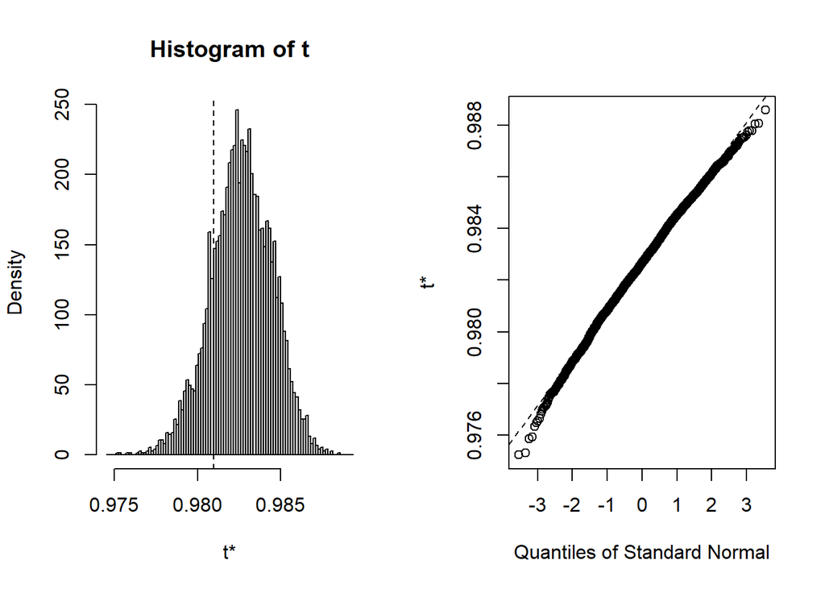

```r
plot(output)
```

## Bootstrap confidence Interval calculation

```r
boot.ci(output, type=c("norm","perc","bca"))
```

```
## BOOTSTRAP CONFIDENCE INTERVAL CALCULATIONS
## Based on 5000 bootstrap replicates
##
## CALL :
## boot.ci(boot.out = output, type = c("norm", "perc", "bca"))
##
## Intervals :
## Level      Normal             Percentile            BCa
## 95%   ( 0.9757,  0.9828 )   ( 0.9789,  0.9860 )   ( 0.9752,  0.9828 )
## Calculations and Intervals on Original Scale
## Warning : BCa Intervals used Extreme Quantiles
## Some BCa intervals may be unstable
```

## logistic regression

The given data is related with direct marketing campaigns of a Portuguese banking institution. The campaign is based on phone calls. My goal in this exercise is to test a few classification models in addition to determining whether or not a customer will subscribe.

This Assignment deals with cross validation and Bootstrap of the regression

## data

```r
#loading dataset
df2 <- read.csv("bank-full.csv",sep = ";",header = T)
```

## summary

```r
summary(df2)
```

```
##       age            job              marital           education
##  Min.   :18.00   Length:45211       Length:45211       Length:45211
##  1st Qu.:33.00   Class :character   Class :character   Class :character
##  Median :39.00   Mode  :character   Mode  :character   Mode  :character
##  Mean   :40.94
##  3rd Qu.:48.00
##  Max.   :95.00
##    default             balance         housing              loan
##  Length:45211       Min.   : -8019   Length:45211       Length:45211
##  Class :character   1st Qu.:    72   Class :character   Class :character
##  Mode  :character   Median :   448   Mode  :character   Mode  :character
##                     Mean   :  1362
##                     3rd Qu.:  1428
##                     Max.   :102127
##    contact               day           month              duration
##  Length:45211       Min.   : 1.00   Length:45211       Min.   :   0.0
##  Class :character   1st Qu.: 8.00   Class :character   1st Qu.: 103.0
##  Mode  :character   Median :16.00   Mode  :character   Median : 180.0
##                     Mean   :15.81                      Mean   : 258.2
##                     3rd Qu.:21.00                      3rd Qu.: 319.0
##                     Max.   :31.00                      Max.   :4918.0
##     campaign          pdays          previous          poutcome
##  Min.   : 1.000   Min.   : -1.0   Min.   :  0.0000   Length:45211
##  1st Qu.: 1.000   1st Qu.: -1.0   1st Qu.:  0.0000   Class :character
##  Median : 2.000   Median : -1.0   Median :  0.0000   Mode  :character
##  Mean   : 2.764   Mean   : 40.2   Mean   :  0.5803
##  3rd Qu.: 3.000   3rd Qu.: -1.0   3rd Qu.:  0.0000
##  Max.   :63.000   Max.   :871.0   Max.   :275.0000
##       y
##  Length:45211
##  Class :character
##  Mode  :character
##
##
##
```

converting y as factor

```r
df2$y <- as.factor(df2$y)
```

## cross validation for 5 folds

```r
set.seed(20)
train_control <- trainControl(method = "cv",
                              number = 5, classProbs = TRUE)
model <- train(y ~., data = df2,
               method = "glm",
               trControl = train_control)
print(model)
```

```
## Generalized Linear Model
##
## 45211 samples
##    16 predictor
##     2 classes: 'no', 'yes'
##
## No pre-processing
## Resampling: Cross-Validated (5 fold)
## Summary of sample sizes: 36169, 36169, 36168, 36169, 36169
## Resampling results:
##
##   Accuracy   Kappa
##   0.9017496  0.4028383
```

## cross validation for 10 folds

```r
set.seed(21)
train_control <- trainControl(method = "cv",
                              number = 10, classProbs = TRUE)
model <- train(y ~., data = df2,
               method = "glm",
               trControl = train_control)
print(model)
```

```
## Generalized Linear Model
##
## 45211 samples
##    16 predictor
##     2 classes: 'no', 'yes'
##
## No pre-processing
## Resampling: Cross-Validated (10 fold)
## Summary of sample sizes: 40690, 40690, 40690, 40691, 40690, 40690, ...
## Resampling results:
##
##   Accuracy   Kappa
##   0.9015507  0.401789
```

## Summary

```r
coef_function <- function(formula, data, indices) {
  d <- data[indices,] #allows select sample
  fit <- lm(formula, data=d) #fit regression model
  return(coef(fit))
}
reps <- boot(data=df2, statistic=coef_function, R=200,formula=y~.)
reps
```

```
##
## ORDINARY NONPARAMETRIC BOOTSTRAP
##
##
## Call:
## boot(data = df2, statistic = coef_function, R = 200, formula = y ~
##     .)
##
##
## Bootstrap Statistics :
##           original        bias     std. error
## t1*   1.067129e+00 -7.730878e-04 1.742884e-02
## t2*   1.786072e-04 -1.930939e-05 1.712240e-04
## t3*  -1.793899e-02 -2.108719e-05 4.928866e-03
## t4*  -2.365127e-02 -4.472255e-04 8.342489e-03
## t5*  -3.275847e-02  9.526733e-06 8.630859e-03
## t6*  -9.861137e-03 -3.080826e-04 6.291170e-03
## t7*   2.831465e-02  2.676196e-04 9.089406e-03
## t8*  -2.080151e-02 -4.040044e-04 7.776467e-03
## t9*  -1.279498e-02  2.486919e-04 5.613919e-03
## t10*  7.089629e-02 -4.446206e-04 1.479671e-02
## t11* -1.046434e-02  7.174885e-05 4.922992e-03
## t12* -5.947853e-03 -1.673529e-04 8.713301e-03
## t13* -2.627419e-02 -8.224882e-04 1.521483e-02
## t14* -1.183573e-02  2.059621e-04 4.011498e-03
## t15*  8.870706e-03  1.068607e-04 4.936080e-03
## t16*  7.058199e-03  9.794865e-05 3.623658e-03
## t17*  2.433329e-02  2.466099e-04 5.449907e-03
## t18*  1.171487e-02  9.615600e-04 7.368609e-03
## t19* -9.954038e-04 -6.621995e-04 7.330336e-03
## t20*  1.234354e-06 -1.192343e-08 4.922098e-07
## t21* -4.888635e-02 -1.891855e-04 3.215269e-03
## t22* -2.390334e-02 -4.027452e-04 2.859935e-03
## t23* -1.213965e-02 -4.692032e-04 6.218322e-03
## t24* -8.818900e-02 -1.208267e-04 4.985072e-03
## t25*  9.793039e-04  1.968047e-05 1.894388e-04
## t26* -7.279723e-02  1.230721e-04 8.237550e-03
## t27*  1.357369e-01 -1.861974e-04 3.365046e-02
## t28* -1.680500e-02  4.209630e-04 1.038270e-02
## t29* -1.126339e-01  4.217588e-04 1.123906e-02
## t30* -7.372312e-02  2.930255e-04 7.808382e-03
## t31*  1.422355e-02  5.947594e-04 9.437308e-03
## t32*  2.781297e-01  2.406415e-03 2.394629e-02
## t33* -3.261152e-02  5.018674e-04 7.364890e-03
## t34* -7.702380e-02  1.027994e-03 8.296976e-03
## t35*  1.566451e-01  8.460873e-05 1.893175e-02
## t36*  1.636217e-01 -8.866100e-04 2.213199e-02
## t37*  4.714968e-04  1.238790e-06 1.054753e-05
## t38* -1.542685e-03 -2.525696e-06 2.977291e-04
## t39* -6.352633e-05  6.630944e-07 4.401348e-05
## t40*  1.066201e-03  2.831461e-04 1.015950e-03
## t41*  2.313374e-02  2.058100e-04 8.470737e-03
## t42*  4.145798e-01  1.230470e-04 1.289496e-02
## t43* -1.603867e-02  5.694438e-04 1.198618e-02
```

## plot

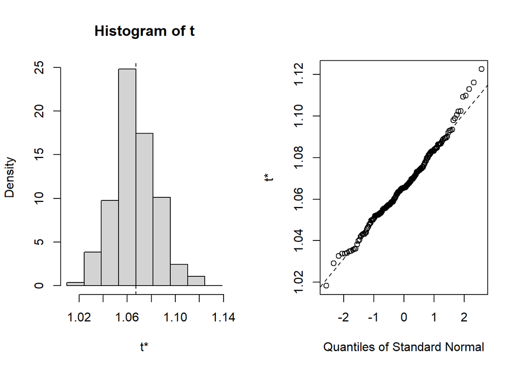

```r
plot(reps, index=1) #intercept of model
```

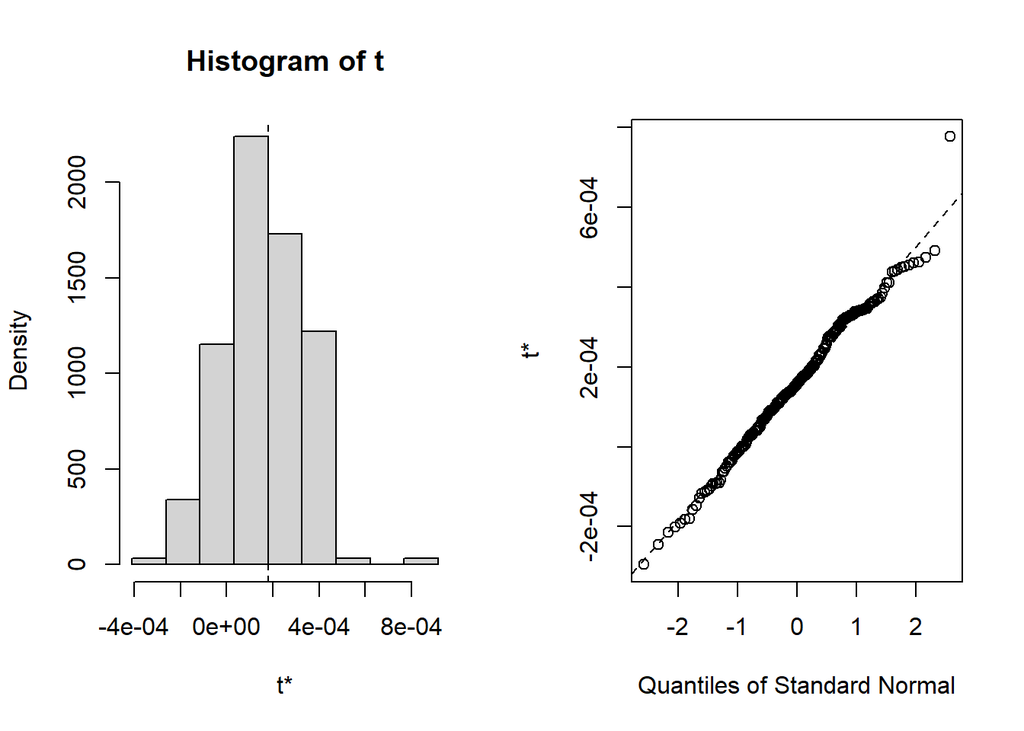

```r
plot(reps, index=2) ##disp predictor variable
```

## Bootstrap confidence Interval calculation

```r
boot.ci(boot.out = reps, type=c("norm","basic","percentile"), index = 1)
```

```
## BOOTSTRAP CONFIDENCE INTERVAL CALCULATIONS
## Based on 200 bootstrap replicates
##
## CALL :
## boot.ci(boot.out = reps, type = c("norm", "basic", "percentile"),
##     index = 1)
##
## Intervals :
## Level      Normal              Basic
## 95%   ( 1.034,  1.102 )   ( 1.025,  1.100 )
## Calculations and Intervals on Original Scale
## Some basic intervals may be unstable
```

```r
boot.ci(boot.out = reps, type=c("norm","basic","percentile"), index = 2)
```

```
## BOOTSTRAP CONFIDENCE INTERVAL CALCULATIONS
## Based on 200 bootstrap replicates
##
## CALL :
## boot.ci(boot.out = reps, type = c("norm", "basic", "percentile"),
##     index = 2)
##
## Intervals :
## Level      Normal              Basic
## 95%   (-0.0001,  0.0005 )   (-0.0001,  0.0005 )
## Calculations and Intervals on Original Scale
## Some basic intervals may be unstable
```